# Risk Factor Analysis

## Outcome Variable

**Outcome Variable:** pers_wast

## Predictor Variables

**Intervention Variable:** exclfeed36

**Adjustment Set:**

- arm
- sex
- brthmon
- W_mage
- meducyrs
- feducyrs
- hhwealth_quart
- hfoodsec
- W_mhtcm
- W_mwtkg
- W_mbmi
- vagbrth
- W_birthwt
- W_birthlen
- W_nrooms
- month
- W_parity
- impfloor
- impsan
- safeh20
- delta_W_mage
- delta_meducyrs
- delta_feducyrs
- delta_hhwealth_quart
- delta_hfoodsec
- delta_W_mhtcm
- delta_W_mwtkg
- delta_W_mbmi
- delta_vagbrth
- delta_W_birthwt
- delta_W_birthlen
- delta_W_nrooms
- delta_month
- delta_W_parity
- delta_impfloor
- delta_impsan
- delta_safeh20

## Stratifying Variables

The analysis was stratified on these variable(s):

- agecat
- studyid
- country

## Data Summary

| agecat | studyid | country | exclfeed36 | pers_wast | n_cell | n |
| --- | --- | --- | --- | --- | --- | --- |
| 0-24 months | CMC-V-BCS-2002 | INDIA | 1 | 0 | 9 | 9 |
| 0-24 months | CMC-V-BCS-2002 | INDIA | 1 | 1 | 0 | 9 |
| 0-24 months | CMC-V-BCS-2002 | INDIA | 0 | 0 | 0 | 9 |
| 0-24 months | CMC-V-BCS-2002 | INDIA | 0 | 1 | 0 | 9 |
| 0-24 months | EE | PAKISTAN | 1 | 0 | 4 | 9 |
| 0-24 months | EE | PAKISTAN | 1 | 1 | 0 | 9 |
| 0-24 months | EE | PAKISTAN | 0 | 0 | 5 | 9 |
| 0-24 months | EE | PAKISTAN | 0 | 1 | 0 | 9 |
| 0-24 months | GMS-Nepal | NEPAL | 1 | 0 | 369 | 528 |
| 0-24 months | GMS-Nepal | NEPAL | 1 | 1 | 54 | 528 |
| 0-24 months | GMS-Nepal | NEPAL | 0 | 0 | 90 | 528 |
| 0-24 months | GMS-Nepal | NEPAL | 0 | 1 | 15 | 528 |
| 0-24 months | IRC | INDIA | 1 | 0 | 0 | 4 |
| 0-24 months | IRC | INDIA | 1 | 1 | 0 | 4 |
| 0-24 months | IRC | INDIA | 0 | 0 | 3 | 4 |
| 0-24 months | IRC | INDIA | 0 | 1 | 1 | 4 |
| 0-24 months | JiVitA-3 | BANGLADESH | 1 | 0 | 5957 | 8221 |
| 0-24 months | JiVitA-3 | BANGLADESH | 1 | 1 | 363 | 8221 |
| 0-24 months | JiVitA-3 | BANGLADESH | 0 | 0 | 1788 | 8221 |
| 0-24 months | JiVitA-3 | BANGLADESH | 0 | 1 | 113 | 8221 |
| 0-24 months | JiVitA-4 | BANGLADESH | 1 | 0 | 3231 | 4495 |
| 0-24 months | JiVitA-4 | BANGLADESH | 1 | 1 | 251 | 4495 |
| 0-24 months | JiVitA-4 | BANGLADESH | 0 | 0 | 908 | 4495 |
| 0-24 months | JiVitA-4 | BANGLADESH | 0 | 1 | 105 | 4495 |
| 0-24 months | Keneba | GAMBIA | 1 | 0 | 572 | 1927 |
| 0-24 months | Keneba | GAMBIA | 1 | 1 | 21 | 1927 |
| 0-24 months | Keneba | GAMBIA | 0 | 0 | 1250 | 1927 |
| 0-24 months | Keneba | GAMBIA | 0 | 1 | 84 | 1927 |
| 0-24 months | LCNI-5 | MALAWI | 1 | 0 | 42 | 240 |
| 0-24 months | LCNI-5 | MALAWI | 1 | 1 | 0 | 240 |

[output cut: 162 more lines]

The following strata were considered:

- agecat: 0-24 months, studyid: CMC-V-BCS-2002, country: INDIA
- agecat: 0-24 months, studyid: EE, country: PAKISTAN
- agecat: 0-24 months, studyid: GMS-Nepal, country: NEPAL
- agecat: 0-24 months, studyid: IRC, country: INDIA
- agecat: 0-24 months, studyid: JiVitA-3, country: BANGLADESH
- agecat: 0-24 months, studyid: JiVitA-4, country: BANGLADESH
- agecat: 0-24 months, studyid: Keneba, country: GAMBIA
- agecat: 0-24 months, studyid: LCNI-5, country: MALAWI
- agecat: 0-24 months, studyid: MAL-ED, country: BANGLADESH
- agecat: 0-24 months, studyid: MAL-ED, country: BRAZIL
- agecat: 0-24 months, studyid: MAL-ED, country: INDIA
- agecat: 0-24 months, studyid: MAL-ED, country: NEPAL
- agecat: 0-24 months, studyid: MAL-ED, country: PERU
- agecat: 0-24 months, studyid: MAL-ED, country: SOUTH AFRICA
- agecat: 0-24 months, studyid: MAL-ED, country: TANZANIA, UNITED REPUBLIC OF
- agecat: 0-24 months, studyid: PROVIDE, country: BANGLADESH
- agecat: 0-24 months, studyid: SAS-FoodSuppl, country: INDIA
- agecat: 0-6 months, studyid: CMC-V-BCS-2002, country: INDIA
- agecat: 0-6 months, studyid: EE, country: PAKISTAN
- agecat: 0-6 months, studyid: GMS-Nepal, country: NEPAL
- agecat: 0-6 months, studyid: IRC, country: INDIA
- agecat: 0-6 months, studyid: JiVitA-3, country: BANGLADESH
- agecat: 0-6 months, studyid: Keneba, country: GAMBIA
- agecat: 0-6 months, studyid: MAL-ED, country: BANGLADESH
- agecat: 0-6 months, studyid: MAL-ED, country: BRAZIL
- agecat: 0-6 months, studyid: MAL-ED, country: INDIA
- agecat: 0-6 months, studyid: MAL-ED, country: NEPAL
- agecat: 0-6 months, studyid: MAL-ED, country: PERU
- agecat: 0-6 months, studyid: MAL-ED, country: SOUTH AFRICA
- agecat: 0-6 months, studyid: MAL-ED, country: TANZANIA, UNITED REPUBLIC OF
- agecat: 0-6 months, studyid: PROVIDE, country: BANGLADESH
- agecat: 6-24 months, studyid: CMC-V-BCS-2002, country: INDIA
- agecat: 6-24 months, studyid: EE, country: PAKISTAN
- agecat: 6-24 months, studyid: GMS-Nepal, country: NEPAL
- agecat: 6-24 months, studyid: IRC, country: INDIA
- agecat: 6-24 months, studyid: JiVitA-3, country: BANGLADESH
- agecat: 6-24 months, studyid: JiVitA-4, country: BANGLADESH
- agecat: 6-24 months, studyid: Keneba, country: GAMBIA
- agecat: 6-24 months, studyid: LCNI-5, country: MALAWI
- agecat: 6-24 months, studyid: MAL-ED, country: BANGLADESH
- agecat: 6-24 months, studyid: MAL-ED, country: BRAZIL
- agecat: 6-24 months, studyid: MAL-ED, country: INDIA
- agecat: 6-24 months, studyid: MAL-ED, country: NEPAL
- agecat: 6-24 months, studyid: MAL-ED, country: PERU
- agecat: 6-24 months, studyid: MAL-ED, country: SOUTH AFRICA
- agecat: 6-24 months, studyid: MAL-ED, country: TANZANIA, UNITED REPUBLIC OF
- agecat: 6-24 months, studyid: PROVIDE, country: BANGLADESH
- agecat: 6-24 months, studyid: SAS-FoodSuppl, country: INDIA

### Dropped Strata

Some strata were dropped due to rare outcomes:

- agecat: 0-24 months, studyid: CMC-V-BCS-2002, country: INDIA
- agecat: 0-24 months, studyid: EE, country: PAKISTAN
- agecat: 0-24 months, studyid: IRC, country: INDIA
- agecat: 0-24 months, studyid: LCNI-5, country: MALAWI
- agecat: 0-24 months, studyid: MAL-ED, country: BANGLADESH
- agecat: 0-24 months, studyid: MAL-ED, country: BRAZIL
- agecat: 0-24 months, studyid: MAL-ED, country: INDIA
- agecat: 0-24 months, studyid: MAL-ED, country: NEPAL
- agecat: 0-24 months, studyid: MAL-ED, country: PERU
- agecat: 0-24 months, studyid: MAL-ED, country: SOUTH AFRICA
- agecat: 0-24 months, studyid: MAL-ED, country: TANZANIA, UNITED REPUBLIC OF
- agecat: 0-24 months, studyid: PROVIDE, country: BANGLADESH
- agecat: 0-24 months, studyid: SAS-FoodSuppl, country: INDIA
- agecat: 0-6 months, studyid: CMC-V-BCS-2002, country: INDIA
- agecat: 0-6 months, studyid: EE, country: PAKISTAN
- agecat: 0-6 months, studyid: IRC, country: INDIA
- agecat: 0-6 months, studyid: JiVitA-3, country: BANGLADESH
- agecat: 0-6 months, studyid: MAL-ED, country: BANGLADESH
- agecat: 0-6 months, studyid: MAL-ED, country: BRAZIL
- agecat: 0-6 months, studyid: MAL-ED, country: INDIA
- agecat: 0-6 months, studyid: MAL-ED, country: NEPAL
- agecat: 0-6 months, studyid: MAL-ED, country: PERU
- agecat: 0-6 months, studyid: MAL-ED, country: SOUTH AFRICA
- agecat: 0-6 months, studyid: MAL-ED, country: TANZANIA, UNITED REPUBLIC OF
- agecat: 0-6 months, studyid: PROVIDE, country: BANGLADESH
- agecat: 6-24 months, studyid: CMC-V-BCS-2002, country: INDIA
- agecat: 6-24 months, studyid: EE, country: PAKISTAN
- agecat: 6-24 months, studyid: IRC, country: INDIA
- agecat: 6-24 months, studyid: LCNI-5, country: MALAWI
- agecat: 6-24 months, studyid: MAL-ED, country: BANGLADESH
- agecat: 6-24 months, studyid: MAL-ED, country: BRAZIL
- agecat: 6-24 months, studyid: MAL-ED, country: INDIA
- agecat: 6-24 months, studyid: MAL-ED, country: NEPAL
- agecat: 6-24 months, studyid: MAL-ED, country: PERU
- agecat: 6-24 months, studyid: MAL-ED, country: SOUTH AFRICA
- agecat: 6-24 months, studyid: MAL-ED, country: TANZANIA, UNITED REPUBLIC OF
- agecat: 6-24 months, studyid: PROVIDE, country: BANGLADESH
- agecat: 6-24 months, studyid: SAS-FoodSuppl, country: INDIA

## Methods Detail

We’re interested in the causal parameters $E[Y_a]$ for all values of $a \in \mathcal{A}$. These parameters represent the mean outcome if, possibly contrary to fact, we intervened to set all units to have $A=a$. Under the randomization and positivity assumptions, these are identified by the statistical parameters $\psi_a=E_W[E_{Y|A,W}(Y|A=a,W)]$. In addition, we’re interested in the mean of $Y$, $E[Y]$ under no intervention (the observed mean). We will estimate these parameters by using SuperLearner to fit the relevant likelihood factors – $E_{Y|A,W}(Y|A=a,W)$ and $p(A=a|W)$, and then updating our likelihood fit using a joint TMLE.

For unadjusted analyses ($W=\{\}$), initial likelihoods were estimated using Lrnr_glm to estimate the simple $E(Y|A)$ and Lrnr_mean to estimate $p(A)$. For adjusted analyses, a small library containing Lrnr_glmnet, Lrnr_xgboost, and Lrnr_mean was used.

Having estimated these parameters, we will then use the delta method to estimate relative risks and attributable risks relative to a prespecified baseline level of $A$.

# Results Detail

## Results Plots

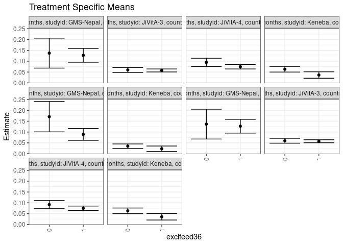

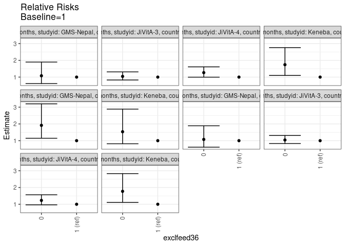

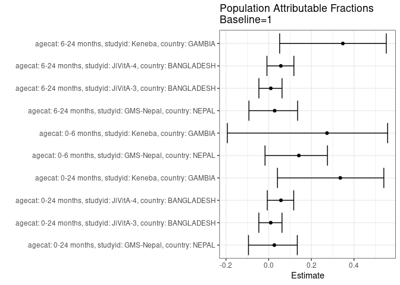

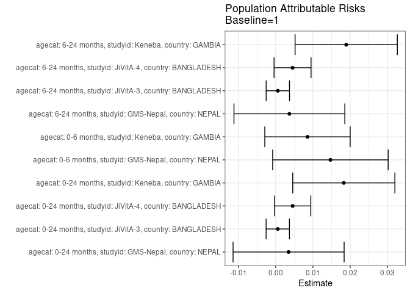

## Results Table

### Parameter: TSM

| agecat | studyid | country | intervention_level | baseline_level | estimate | ci_lower | ci_upper |
| --- | --- | --- | --- | --- | --- | --- | --- |
| 0-24 months | GMS-Nepal | NEPAL | 1 | NA | 0.1272190 | 0.0952963 | 0.1591418 |
| 0-24 months | GMS-Nepal | NEPAL | 0 | NA | 0.1373563 | 0.0682096 | 0.2065031 |
| 0-24 months | JiVitA-3 | BANGLADESH | 1 | NA | 0.0573424 | 0.0504411 | 0.0642437 |
| 0-24 months | JiVitA-3 | BANGLADESH | 0 | NA | 0.0597389 | 0.0484724 | 0.0710054 |
| 0-24 months | JiVitA-4 | BANGLADESH | 1 | NA | 0.0746445 | 0.0642198 | 0.0850693 |
| 0-24 months | JiVitA-4 | BANGLADESH | 0 | NA | 0.0945412 | 0.0752590 | 0.1138235 |
| 0-24 months | Keneba | GAMBIA | 1 | NA | 0.0361982 | 0.0213172 | 0.0510792 |
| 0-24 months | Keneba | GAMBIA | 0 | NA | 0.0630380 | 0.0499999 | 0.0760762 |
| 0-6 months | GMS-Nepal | NEPAL | 1 | NA | 0.0891449 | 0.0618144 | 0.1164754 |
| 0-6 months | GMS-Nepal | NEPAL | 0 | NA | 0.1707474 | 0.1006688 | 0.2408260 |
| 0-6 months | Keneba | GAMBIA | 1 | NA | 0.0226953 | 0.0099838 | 0.0354068 |
| 0-6 months | Keneba | GAMBIA | 0 | NA | 0.0348127 | 0.0246858 | 0.0449396 |
| 6-24 months | GMS-Nepal | NEPAL | 1 | NA | 0.1270025 | 0.0950929 | 0.1589122 |
| 6-24 months | GMS-Nepal | NEPAL | 0 | NA | 0.1365188 | 0.0676674 | 0.2053703 |
| 6-24 months | JiVitA-3 | BANGLADESH | 1 | NA | 0.0573290 | 0.0504368 | 0.0642213 |
| 6-24 months | JiVitA-3 | BANGLADESH | 0 | NA | 0.0597234 | 0.0484516 | 0.0709953 |
| 6-24 months | JiVitA-4 | BANGLADESH | 1 | NA | 0.0746717 | 0.0641985 | 0.0851449 |
| 6-24 months | JiVitA-4 | BANGLADESH | 0 | NA | 0.0918427 | 0.0729546 | 0.1107309 |
| 6-24 months | Keneba | GAMBIA | 1 | NA | 0.0355491 | 0.0206395 | 0.0504588 |
| 6-24 months | Keneba | GAMBIA | 0 | NA | 0.0630011 | 0.0499596 | 0.0760427 |

### Parameter: E(Y)

| agecat | studyid | country | intervention_level | baseline_level | estimate | ci_lower | ci_upper |
| --- | --- | --- | --- | --- | --- | --- | --- |
| 0-24 months | GMS-Nepal | NEPAL | NA | NA | 0.1306818 | 0.1019052 | 0.1594584 |
| 0-24 months | JiVitA-3 | BANGLADESH | NA | NA | 0.0579005 | 0.0521352 | 0.0636658 |
| 0-24 months | JiVitA-4 | BANGLADESH | NA | NA | 0.0791991 | 0.0699871 | 0.0884111 |
| 0-24 months | Keneba | GAMBIA | NA | NA | 0.0544888 | 0.0443519 | 0.0646258 |
| 0-6 months | GMS-Nepal | NEPAL | NA | NA | 0.1038462 | 0.0776009 | 0.1300914 |
| 0-6 months | Keneba | GAMBIA | NA | NA | 0.0312326 | 0.0231789 | 0.0392862 |
| 6-24 months | GMS-Nepal | NEPAL | NA | NA | 0.1306818 | 0.1019052 | 0.1594584 |
| 6-24 months | JiVitA-3 | BANGLADESH | NA | NA | 0.0579005 | 0.0521352 | 0.0636658 |
| 6-24 months | JiVitA-4 | BANGLADESH | NA | NA | 0.0791991 | 0.0699871 | 0.0884111 |
| 6-24 months | Keneba | GAMBIA | NA | NA | 0.0544888 | 0.0443519 | 0.0646258 |

### Parameter: RR

| agecat | studyid | country | intervention_level | baseline_level | estimate | ci_lower | ci_upper |
| --- | --- | --- | --- | --- | --- | --- | --- |
| 0-24 months | GMS-Nepal | NEPAL | 1 | 1 | 1.000000 | 1.0000000 | 1.000000 |
| 0-24 months | GMS-Nepal | NEPAL | 0 | 1 | 1.079684 | 0.6144758 | 1.897093 |
| 0-24 months | JiVitA-3 | BANGLADESH | 1 | 1 | 1.000000 | 1.0000000 | 1.000000 |
| 0-24 months | JiVitA-3 | BANGLADESH | 0 | 1 | 1.041793 | 0.8281110 | 1.310613 |
| 0-24 months | JiVitA-4 | BANGLADESH | 1 | 1 | 1.000000 | 1.0000000 | 1.000000 |
| 0-24 months | JiVitA-4 | BANGLADESH | 0 | 1 | 1.266553 | 0.9955577 | 1.611314 |
| 0-24 months | Keneba | GAMBIA | 1 | 1 | 1.000000 | 1.0000000 | 1.000000 |
| 0-24 months | Keneba | GAMBIA | 0 | 1 | 1.741468 | 1.0990540 | 2.759382 |
| 0-6 months | GMS-Nepal | NEPAL | 1 | 1 | 1.000000 | 1.0000000 | 1.000000 |
| 0-6 months | GMS-Nepal | NEPAL | 0 | 1 | 1.915391 | 1.1466205 | 3.199597 |
| 0-6 months | Keneba | GAMBIA | 1 | 1 | 1.000000 | 1.0000000 | 1.000000 |
| 0-6 months | Keneba | GAMBIA | 0 | 1 | 1.533916 | 0.8158177 | 2.884099 |
| 6-24 months | GMS-Nepal | NEPAL | 1 | 1 | 1.000000 | 1.0000000 | 1.000000 |
| 6-24 months | GMS-Nepal | NEPAL | 0 | 1 | 1.074930 | 0.6116613 | 1.889076 |
| 6-24 months | JiVitA-3 | BANGLADESH | 1 | 1 | 1.000000 | 1.0000000 | 1.000000 |
| 6-24 months | JiVitA-3 | BANGLADESH | 0 | 1 | 1.041766 | 0.8279803 | 1.310752 |
| 6-24 months | JiVitA-4 | BANGLADESH | 1 | 1 | 1.000000 | 1.0000000 | 1.000000 |
| 6-24 months | JiVitA-4 | BANGLADESH | 0 | 1 | 1.229953 | 0.9655298 | 1.566793 |
| 6-24 months | Keneba | GAMBIA | 1 | 1 | 1.000000 | 1.0000000 | 1.000000 |
| 6-24 months | Keneba | GAMBIA | 0 | 1 | 1.772226 | 1.1101041 | 2.829272 |

### Parameter: PAR

| agecat | studyid | country | intervention_level | baseline_level | estimate | ci_lower | ci_upper |
| --- | --- | --- | --- | --- | --- | --- | --- |
| 0-24 months | GMS-Nepal | NEPAL | 1 | NA | 0.0034628 | -0.0114545 | 0.0183801 |
| 0-24 months | JiVitA-3 | BANGLADESH | 1 | NA | 0.0005581 | -0.0025762 | 0.0036924 |
| 0-24 months | JiVitA-4 | BANGLADESH | 1 | NA | 0.0045546 | -0.0003186 | 0.0094277 |
| 0-24 months | Keneba | GAMBIA | 1 | NA | 0.0182906 | 0.0045737 | 0.0320075 |
| 0-6 months | GMS-Nepal | NEPAL | 1 | NA | 0.0147012 | -0.0008104 | 0.0302128 |
| 0-6 months | Keneba | GAMBIA | 1 | NA | 0.0085373 | -0.0029296 | 0.0200041 |
| 6-24 months | GMS-Nepal | NEPAL | 1 | NA | 0.0036793 | -0.0112079 | 0.0185665 |
| 6-24 months | JiVitA-3 | BANGLADESH | 1 | NA | 0.0005715 | -0.0025618 | 0.0037047 |
| 6-24 months | JiVitA-4 | BANGLADESH | 1 | NA | 0.0045274 | -0.0004425 | 0.0094973 |
| 6-24 months | Keneba | GAMBIA | 1 | NA | 0.0189397 | 0.0052080 | 0.0326714 |

### Parameter: PAF

| agecat | studyid | country | intervention_level | baseline_level | estimate | ci_lower | ci_upper |
| --- | --- | --- | --- | --- | --- | --- | --- |
| 0-24 months | GMS-Nepal | NEPAL | 1 | NA | 0.0264980 | -0.0945404 | 0.1341515 |
| 0-24 months | JiVitA-3 | BANGLADESH | 1 | NA | 0.0096390 | -0.0461380 | 0.0624421 |
| 0-24 months | JiVitA-4 | BANGLADESH | 1 | NA | 0.0575078 | -0.0064675 | 0.1174166 |
| 0-24 months | Keneba | GAMBIA | 1 | NA | 0.3356767 | 0.0411876 | 0.5397165 |
| 0-6 months | GMS-Nepal | NEPAL | 1 | NA | 0.1415674 | -0.0170972 | 0.2754807 |
| 0-6 months | Keneba | GAMBIA | 1 | NA | 0.2733454 | -0.1935358 | 0.5575945 |
| 6-24 months | GMS-Nepal | NEPAL | 1 | NA | 0.0281545 | -0.0926439 | 0.1355980 |
| 6-24 months | JiVitA-3 | BANGLADESH | 1 | NA | 0.0098698 | -0.0458878 | 0.0626549 |
| 6-24 months | JiVitA-4 | BANGLADESH | 1 | NA | 0.0571648 | -0.0081086 | 0.1182118 |
| 6-24 months | Keneba | GAMBIA | 1 | NA | 0.3475886 | 0.0514792 | 0.5512585 |